# Problem statement - Term Deposit Subcription

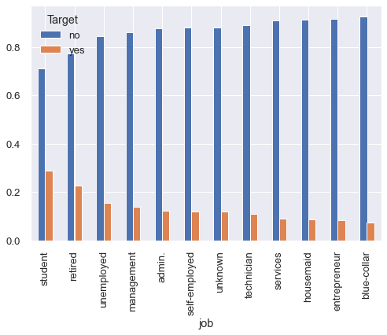

```python
pd.crosstab(pdata['job'], pdata['Target'], normalize='index').sort_values(by='yes',ascending=False ).plot(kind='bar')
```

- We can see that students and retired people are more likely to sucbcribe for the term deposit.
- It is not surprising to see such a pattern because the main investment objective of older people is saving for retirement while the middle-aged group tend to be more aggressive with a main objective of generating high investment income. Term deposits, as the least risky investment tool, are more preferable to the eldest.
- The youngest may not have enough money or professional knowledge to engage in sophisticated investments, such as stocks and mutual funds. Term deposits provide liquidity and generate interest incomes that are higher than the regular saving account, so term deposits are ideal investments for students.

```python
pd.crosstab(pdata['marital'], pdata['Target'], normalize='index').sort_values(by='yes',ascending=False )
```

| Target marital | no | yes |
| --- | --- | --- |
| single | 0.850508 | 0.149492 |
| divorced | 0.880545 | 0.119455 |
| married | 0.898765 | 0.101235 |

```python
pd.crosstab(pdata['education'], pdata['Target'], normalize='index').sort_values(by='yes',ascending=False )
```

| Target education | no | yes |
| --- | --- | --- |
| tertiary | 0.849936 | 0.150064 |
| unknown | 0.864297 | 0.135703 |
| secondary | 0.894406 | 0.105594 |
| primary | 0.913735 | 0.086265 |

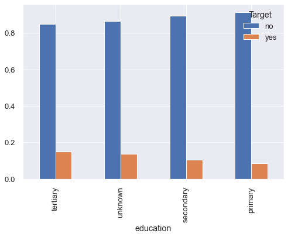

```python
pd.crosstab(pdata['education'], pdata['Target'], normalize='index').sort_values(by='yes',ascending=False ).plot(kind='bar')
```

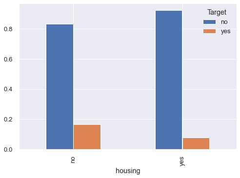

```python
pd.crosstab(pdata['housing'], pdata['Target'], normalize='index').sort_values(by='yes',ascending=False ).plot(kind='bar')
```

```python
pd.crosstab(pdata['housing'], pdata['Target'], normalize='index').sort_values(by='yes',ascending=False )
```

| Target housing | no | yes |
| --- | --- | --- |
| no | 0.832976 | 0.167024 |
| yes | 0.923000 | 0.077000 |

```python
pd.crosstab(pdata['loan'], pdata['Target'], normalize='index').sort_values(by='yes',ascending=False )
```

| Target loan | no | yes |
| --- | --- | --- |
| no | 0.873443 | 0.126557 |
| yes | 0.933186 | 0.066814 |

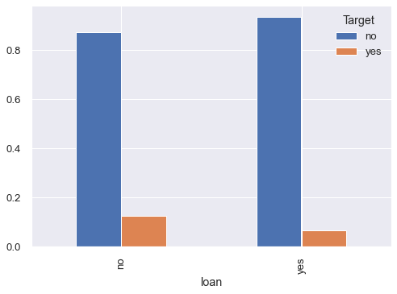

```python
pd.crosstab(pdata['loan'], pdata['Target'], normalize='index').sort_values(by='yes',ascending=False ).plot(kind='bar')
```

```python
pd.crosstab(pdata['contact'], pdata['Target'], normalize='index').sort_values(by='yes',ascending=False )
```

| Target contact | no | yes |
| --- | --- | --- |
| cellular | 0.850811 | 0.149189 |
| telephone | 0.865795 | 0.134205 |
| unknown | 0.959293 | 0.040707 |

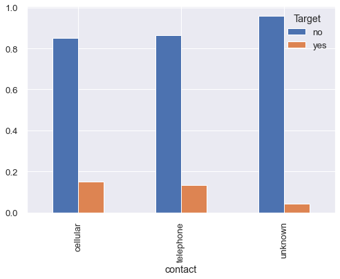

```python
pd.crosstab(pdata['contact'], pdata['Target'], normalize='index').sort_values(by='yes',ascending=False ).plot(kind='bar')
```

| contact month | cellular | telephone | unknown | All |
| --- | --- | --- | --- | --- |
| All | 29285 | 2906 | 13020 | 45211 |
| may | 5331 | 460 | 7975 | 13766 |
| jul | 5767 | 852 | 276 | 6895 |
| aug | 5950 | 246 | 51 | 6247 |
| jun | 729 | 80 | 4532 | 5341 |
| nov | 3540 | 379 | 51 | 3970 |
| apr | 2727 | 199 | 6 | 2932 |
| feb | 2362 | 274 | 13 | 2649 |
| jan | 1265 | 129 | 9 | 1403 |
| oct | 557 | 131 | 50 | 738 |
| sep | 466 | 66 | 47 | 579 |
| mar | 417 | 53 | 7 | 477 |
| dec | 174 | 37 | 3 | 214 |

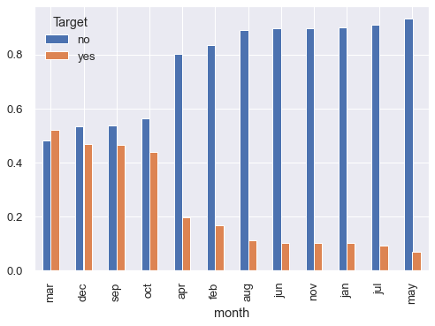

```python
pd.crosstab(pdata['month'], pdata['Target'], normalize='index').sort_values(by='yes',ascending=False ).plot(kind='bar')
print()
pd.crosstab(pdata['month'],pdata['contact'],margins=True).sort_values(by='All',ascending=False)
```

```python
pd.crosstab(pdata['day'], pdata['Target'], normalize='index').sort_values(by='yes',ascending=False )
```

| Target day | no | yes |
| --- | --- | --- |
| 1 | 0.720497 | 0.279503 |
| 10 | 0.769084 | 0.230916 |
| 30 | 0.826948 | 0.173052 |
| 22 | 0.829834 | 0.170166 |
| 3 | 0.835032 | 0.164968 |
| 4 | 0.840830 | 0.159170 |
| 25 | 0.841667 | 0.158333 |
| 12 | 0.847785 | 0.152215 |
| 13 | 0.847950 | 0.152050 |
| 2 | 0.859242 | 0.140758 |
| 15 | 0.860247 | 0.139753 |
| 24 | 0.861298 | 0.138702 |
| 16 | 0.864311 | 0.135689 |
| 23 | 0.865815 | 0.134185 |
| 27 | 0.866191 | 0.133809 |
| 11 | 0.877620 | 0.122380 |
| 9 | 0.885330 | 0.114670 |
| 14 | 0.886364 | 0.113636 |
| 5 | 0.887435 | 0.112565 |
| 26 | 0.887923 | 0.112077 |
| 8 | 0.890879 | 0.109121 |
| 21 | 0.900790 | 0.099210 |
| 18 | 0.901213 | 0.098787 |
| 6 | 0.906315 | 0.093685 |
| 17 | 0.909232 | 0.090768 |
| 7 | 0.913594 | 0.086406 |
| 28 | 0.921858 | 0.078142 |
| 29 | 0.926074 | 0.073926 |
| 31 | 0.928460 | 0.071540 |
| 20 | 0.930233 | 0.069767 |
| 19 | 0.930563 | 0.069437 |

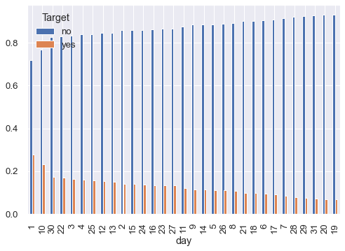

```python
pd.crosstab(pdata['day'], pdata['Target'], normalize='index').sort_values(by='yes',ascending=False ).plot(kind='bar')
```

```python
pd.crosstab(pdata['default'], pdata['Target'], normalize='index').sort_values(by='yes',ascending=False )
```

| Target default | no | yes |
| --- | --- | --- |
| no | 0.882039 | 0.117961 |
| yes | 0.936196 | 0.063804 |

```python
pdata["default"].value_counts(normalize=True)
```

```
no     0.981973
yes    0.018027
Name: default, dtype: float64
```

# Missing Data Handling

- No null values within the data.
- Day - 31 unique days is normal and data normally distributed with some fluctuations
- Month - 12 unique month is normal can be used as it is.
- Age, day, month, balance, duration, pdays, campaign and previous - numeric no changes
- Age is abosolutely fine to have outlaters as retired category has higher potential Term-Deposite customers so will retain as it is.
- Job - has been categorized as below : unknown = -1, technician, services, housemain = 3, unemployed & student = 6, self-employed & entrepreneur both same as 7, Blue-Collared & Management 1 & 2 respectively.
- Education - unknown =-1.
- Contact - Unknown shows significant differences so will include as different category.
- Poutcome - Unknown shows high volume - Others & Unknown both encoded as -1.
- Education - Unknown shows significance so retain as it is encoded -1.
- Poutcome - Unknown shows significance so retain as it is encoded -1
- Marital - OneHotEncoded because single/married/divorced to be used as it is with categories
- All object variables (Target,default,housing,loan,job, education, poutcome,month have been converted to int64 & uint8

# Preparing the Data for Analysis

```python
#Define Categories
ReplaceStructure = {
                "Target":      {"no": 0, "yes": 1},
                "default":     {"no": 0, "yes": 1},
                "housing":     {"no": 0, "yes": 1},
                "loan":        {"no": 0, "yes": 1},
                "job":         {"blue-collar": 1, "management": 2, "technician": 3, "services": 3, "housemaid": 3, "admin.": 4, "retired": 5, "unemployed": 6,
                               "student": 6, "self-employed": 7, "entrepreneur": 7, "unknown": -1},
                "education":  {"primary": 1, "secondary":2 , "tertiary": 3, "unknown": -1},
                "poutcome":   {"success": 1, "failure": 2 , "other": -1, "unknown": -1},
                "month": {'jan':1,'feb':2,'mar':3, 'apr':4, 'may':5, 'jun':6, 'jul':7, 'aug':8, 'sep':9, 'oct':10, 'nov':11, 'dec':12}
                    }
```

```python
#One hot encoding
OneHotEncoding=["marital","contact"]
```

```python
pdata=pdata.replace(ReplaceStructure)
pdata=pd.get_dummies(pdata, columns=OneHotEncoding)
pdata.head(10)
```

|  | age | job | education | default | balance | housing | loan | day | month | duration | ... | pdays | previous | poutcome | Target | marital_divorced | marital_married | marital_single | contact_cellular | contact_telephone | contact_unknown |
| --- | --- | --- | --- | --- | --- | --- | --- | --- | --- | --- | --- | --- | --- | --- | --- | --- | --- | --- | --- | --- | --- |
| 0 | 58 | 2 | 3 | 0 | 2143 | 1 | 0 | 5 | 5 | 261 | ... | -1 | 0 | -1 | 0 | 0 | 1 | 0 | 0 | 0 | 1 |
| 1 | 44 | 3 | 2 | 0 | 29 | 1 | 0 | 5 | 5 | 151 | ... | -1 | 0 | -1 | 0 | 0 | 0 | 1 | 0 | 0 | 1 |
| 2 | 33 | 7 | 2 | 0 | 2 | 1 | 1 | 5 | 5 | 76 | ... | -1 | 0 | -1 | 0 | 0 | 1 | 0 | 0 | 0 | 1 |
| 3 | 47 | 1 | -1 | 0 | 1506 | 1 | 0 | 5 | 5 | 92 | ... | -1 | 0 | -1 | 0 | 0 | 1 | 0 | 0 | 0 | 1 |
| 4 | 33 | -1 | -1 | 0 | 1 | 0 | 0 | 5 | 5 | 198 | ... | -1 | 0 | -1 | 0 | 0 | 0 | 1 | 0 | 0 | 1 |
| 5 | 35 | 2 | 3 | 0 | 231 | 1 | 0 | 5 | 5 | 139 | ... | -1 | 0 | -1 | 0 | 0 | 1 | 0 | 0 | 0 | 1 |
| 6 | 28 | 2 | 3 | 0 | 447 | 1 | 1 | 5 | 5 | 217 | ... | -1 | 0 | -1 | 0 | 0 | 0 | 1 | 0 | 0 | 1 |
| 7 | 42 | 7 | 3 | 1 | 2 | 1 | 0 | 5 | 5 | 380 | ... | -1 | 0 | -1 | 0 | 1 | 0 | 0 | 0 | 0 | 1 |
| 8 | 58 | 5 | 1 | 0 | 121 | 1 | 0 | 5 | 5 | 50 | ... | -1 | 0 | -1 | 0 | 0 | 1 | 0 | 0 | 0 | 1 |
| 9 | 43 | 3 | 2 | 0 | 593 | 1 | 0 | 5 | 5 | 55 | ... | -1 | 0 | -1 | 0 | 0 | 0 | 1 | 0 | 0 | 1 |

10 rows × 21 columns

```python
pdata.info()
```

```
<class 'pandas.core.frame.DataFrame'>
RangeIndex: 45211 entries, 0 to 45210
Data columns (total 21 columns):
 #   Column             Non-Null Count  Dtype
---  ------             --------------  -----
 0   age                45211 non-null  int64
 1   job                45211 non-null  int64
 2   education          45211 non-null  int64
 3   default            45211 non-null  int64
 4   balance            45211 non-null  int64
 5   housing            45211 non-null  int64
 6   loan               45211 non-null  int64
 7   day                45211 non-null  int64
 8   month              45211 non-null  int64
 9   duration           45211 non-null  int64
 10  campaign           45211 non-null  int64
 11  pdays              45211 non-null  int64
 12  previous           45211 non-null  int64
 13  poutcome           45211 non-null  int64
 14  Target             45211 non-null  int64
 15  marital_divorced   45211 non-null  uint8
 16  marital_married    45211 non-null  uint8
 17  marital_single     45211 non-null  uint8
 18  contact_cellular   45211 non-null  uint8
 19  contact_telephone  45211 non-null  uint8
 20  contact_unknown    45211 non-null  uint8
dtypes: int64(15), uint8(6)
memory usage: 5.4 MB
```

```python
pdata.describe().T
```

|  | count | mean | std | min | 25% | 50% | 75% | max |
| --- | --- | --- | --- | --- | --- | --- | --- | --- |
| age | 45211.0 | 40.936210 | 10.618762 | 18.0 | 33.0 | 39.0 | 48.0 | 95.0 |
| job | 45211.0 | 2.969300 | 1.736982 | -1.0 | 2.0 | 3.0 | 4.0 | 7.0 |
| education | 45211.0 | 2.019442 | 0.902795 | -1.0 | 2.0 | 2.0 | 3.0 | 3.0 |
| default | 45211.0 | 0.018027 | 0.133049 | 0.0 | 0.0 | 0.0 | 0.0 | 1.0 |
| balance | 45211.0 | 1362.272058 | 3044.765829 | -8019.0 | 72.0 | 448.0 | 1428.0 | 102127.0 |
| housing | 45211.0 | 0.555838 | 0.496878 | 0.0 | 0.0 | 1.0 | 1.0 | 1.0 |
| loan | 45211.0 | 0.160226 | 0.366820 | 0.0 | 0.0 | 0.0 | 0.0 | 1.0 |
| day | 45211.0 | 15.806419 | 8.322476 | 1.0 | 8.0 | 16.0 | 21.0 | 31.0 |
| month | 45211.0 | 6.144655 | 2.408034 | 1.0 | 5.0 | 6.0 | 8.0 | 12.0 |
| duration | 45211.0 | 258.163080 | 257.527812 | 0.0 | 103.0 | 180.0 | 319.0 | 4918.0 |
| campaign | 45211.0 | 2.763841 | 3.098021 | 1.0 | 1.0 | 2.0 | 3.0 | 63.0 |
| pdays | 45211.0 | 40.197828 | 100.128746 | -1.0 | -1.0 | -1.0 | -1.0 | 871.0 |
| previous | 45211.0 | 0.580323 | 2.303441 | 0.0 | 0.0 | 0.0 | 0.0 | 275.0 |
| poutcome | 45211.0 | -0.607949 | 0.977562 | -1.0 | -1.0 | -1.0 | -1.0 | 2.0 |
| Target | 45211.0 | 0.116985 | 0.321406 | 0.0 | 0.0 | 0.0 | 0.0 | 1.0 |
| marital_divorced | 45211.0 | 0.115171 | 0.319232 | 0.0 | 0.0 | 0.0 | 0.0 | 1.0 |
| marital_married | 45211.0 | 0.601933 | 0.489505 | 0.0 | 0.0 | 1.0 | 1.0 | 1.0 |
| marital_single | 45211.0 | 0.282896 | 0.450411 | 0.0 | 0.0 | 0.0 | 1.0 | 1.0 |
| contact_cellular | 45211.0 | 0.647741 | 0.477680 | 0.0 | 0.0 | 1.0 | 1.0 | 1.0 |
| contact_telephone | 45211.0 | 0.064276 | 0.245247 | 0.0 | 0.0 | 0.0 | 0.0 | 1.0 |
| contact_unknown | 45211.0 | 0.287983 | 0.452828 | 0.0 | 0.0 | 0.0 | 1.0 | 1.0 |

```python
pdata.groupby(["Target"]).mean().T
```

| Target | 0 | 1 |
| --- | --- | --- |
| age | 40.838986 | 41.670070 |
| job | 2.928586 | 3.276612 |
| education | 2.005761 | 2.122708 |
| default | 0.019112 | 0.009832 |
| balance | 1303.714969 | 1804.267915 |
| housing | 0.581008 | 0.365854 |
| loan | 0.169330 | 0.091511 |
| day | 15.892290 | 15.158253 |
| month | 6.128250 | 6.268482 |
| duration | 221.182806 | 537.294574 |
| campaign | 2.846350 | 2.141047 |
| pdays | 36.421372 | 68.702968 |
| previous | 0.502154 | 1.170354 |
| poutcome | -0.651445 | -0.279637 |
| marital_divorced | 0.114849 | 0.117603 |
| marital_married | 0.612670 | 0.520892 |
| marital_single | 0.272481 | 0.361505 |
| contact_cellular | 0.624117 | 0.826054 |
| contact_telephone | 0.063023 | 0.073738 |
| contact_unknown | 0.312860 | 0.100208 |

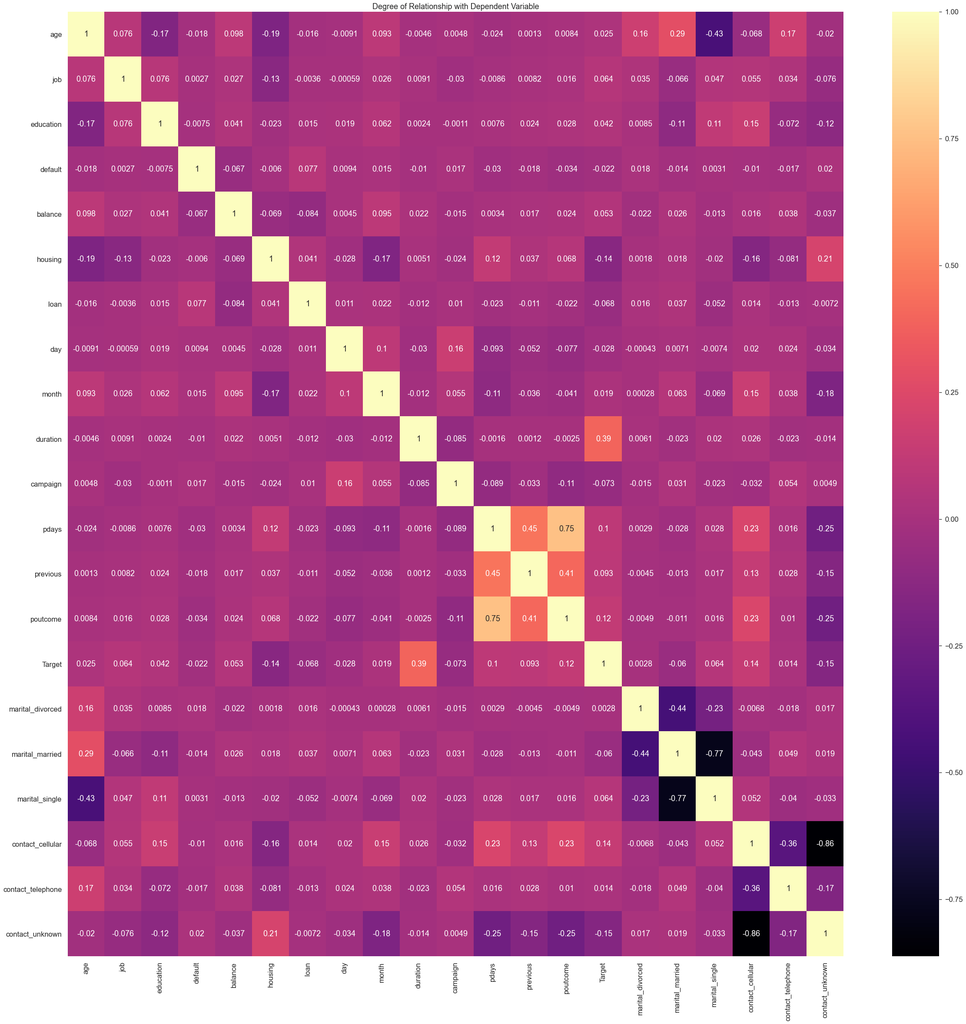

```python
k=pdata.corr()
plt.figure (figsize=(40,40))
sns.set(font_scale=1.5)
sns.heatmap(k, annot=True, cmap='magma').set_title('Degree of Relationship with Dependent Variable')
plt.show()
```

**Observation**

**From the heatmap its was observed that Pdays and Previous highly correlated (0.45), need to drop one variable for Logistic Regression to avoid multi-collinearity**</font>

# Split - Data 70-30%

```python
# X Independent variable
# Its looks like Pdays and Previous highly correlated (0.45), need to drop one variable for Logistic Regression
#to avoid multi-collinearity and Previous has less correlated with Target comparing pdays.

X = pdata.drop(['Target','default','previous','marital_divorced','contact_telephone'],axis=1)

#Y Dependant variable
Y = pdata['Target']

#Split data 70% train and 30% test
X_train, X_test, y_train, y_test = train_test_split(X, Y, test_size=0.3, random_state=1)
```

```python
#Train and Test percentage.

print("{0:0.4f}% Training data".format((len(X_train)/len(pdata.index)) * 100))
print("{0:0.4f}% Test data".format((len(X_test)/len(pdata.index)) * 100))
```

```
69.9985% Training data
30.0015% Test data
```

```python
#Original
print("Original - Target - Yes    : {0} ({1:0.2f}%)".format(len(pdata.loc[pdata['Target'] == 1]), (len(pdata.loc[pdata['Target'] == 1])/len(pdata.index)) * 100))
print("Original - Target - No     : {0} ({1:0.2f}%)".format(len(pdata.loc[pdata['Target'] == 0]), (len(pdata.loc[pdata['Target'] == 0])/len(pdata.index)) * 100))
print("")

#Training
print("Training - Target - Yes    : {0} ({1:0.2f}%)".format(len(y_train[y_train[:] == 1]), (len(y_train[y_train[:] == 1])/len(y_train)) * 100))
print("Training - Target - No     : {0} ({1:0.2f}%)".format(len(y_train[y_train[:] == 0]), (len(y_train[y_train[:] == 0])/len(y_train)) * 100))
print("")

#Testing
print("Test - Target - Yes        : {0} ({1:0.2f}%)".format(len(y_test[y_test[:] == 1]), (len(y_test[y_test[:] == 1])/len(y_test)) * 100))
print("Test - Target - No         : {0} ({1:0.2f}%)".format(len(y_test[y_test[:] == 0]), (len(y_test[y_test[:] == 0])/len(y_test)) * 100))
```

```
Original - Target - Yes    : 5289 (11.70%)
Original - Target - No     : 39922 (88.30%)

Training - Target - Yes    : 3738 (11.81%)
Training - Target - No     : 27909 (88.19%)

Test - Target - Yes        : 1551 (11.43%)
Test - Target - No         : 12013 (88.57%)
```

# Logistic Regression

**Data Preparation for Logistic Regression**

**Assumption is completely different comparing Logistic Regression and Decision Tree - so separate data preparation needed for the both the Algorithm and different Ensemble Technique**</font>

```python
#Logistic Regression
LR = LogisticRegression(random_state=42,penalty='l1',solver='liblinear',max_iter=10000,C = 1)
LR.fit(X_train, y_train)

#predict on test
y_predict= LR.predict(X_test)

print("Training: ",LR.score(X_train, y_train).round(4))
print("Testing: ",LR.score(X_test, y_test).round(4))
```

```
Training:  0.8918
Testing:  0.8902
```

```python
Predicts_Train = LR.predict(X_train)
Predicts_Test = LR.predict(X_test)

score_LR = accuracy_score(y_test, Predicts_Test)

# Confusion matrix
pd.crosstab(y_test, Predicts_Test, rownames=['Actual'], colnames=['Predicted'])
```

| Predicted Actual | 0 | 1 |
| --- | --- | --- |
| 0 | 11751 | 262 |
| 1 | 1227 | 324 |

```
Trainig accuracy 0.8918

Testing accuracy 0.8902

Confusion Matrix
```

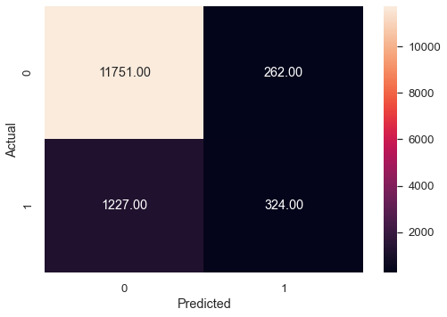

```
None

 Performance Indicators

Recall: 0.2089

Precision: 0.5529

F1 Score: 0.3032

Roc Auc Score: 0.5935
```

```python
## function to get confusion matrix in a proper format
sns.set(font_scale=1.2)
def draw_cm( actual, predicted ):
    cm = confusion_matrix(y_test , Predicts_Test)
    sns.heatmap(cm, annot=True,  fmt='.2f', xticklabels = [0,1] , yticklabels = [0,1] )
    plt.ylabel('Actual')
    plt.xlabel('Predicted')
    plt.show()

print("Trainig accuracy",LR.score(X_train,y_train).round(4))
print()
print("Testing accuracy",LR.score(X_test, y_test).round(4))
print()
print('Confusion Matrix')
print(draw_cm(y_test,y_predict))
print('\n',"Performance Indicators",'\n')
print("Recall:",recall_score(y_test,y_predict).round(4))
print()
print("Precision:",precision_score(y_test,y_predict).round(4))
print()
print("F1 Score:",f1_score(y_test,y_predict).round(4))
print()
print("Roc Auc Score:",roc_auc_score(y_test,y_predict).round(4))
```

```python
# Model performance
#from sklearn import metrics
#Y_predicts = np.around(LR.predict(X_test))
#print(metrics.classification_report(y_test,Y_predicts))

from sklearn import metrics
Y_predicts = np.around(LR.predict(X_test))
print("Precision Score: ",metrics.precision_score(y_test,Y_predicts).round(2),'\n')
print(metrics.classification_report(y_test,Y_predicts))
```

```
Precision Score:  0.55

              precision    recall  f1-score   support

           0       0.91      0.98      0.94     12013
           1       0.55      0.21      0.30      1551

    accuracy                           0.89     13564
   macro avg       0.73      0.59      0.62     13564
weighted avg       0.87      0.89      0.87     13564
```

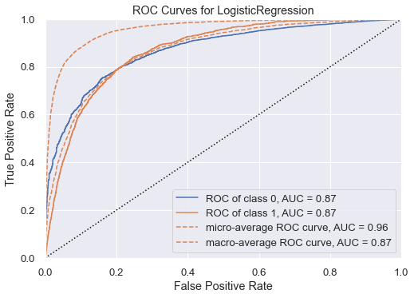

```python
# ROCAUC - Visualize model performance with yellowbrick library
from yellowbrick.classifier import  ROCAUC

roc = ROCAUC(LR)
roc.fit(X_train, y_train)
roc.score(X_test, y_test)
roc.show()
```

```python
#Store the accuracy results for each model in a dataframe for final comparison
Result = pd.DataFrame({'Method':['Logistic Regression'], 'Accuracy': score_LR})
Final = Result[['Method', 'Accuracy']]
Final
```

|  | Method | Accuracy |
| --- | --- | --- |
| 0 | Logistic Regression | 0.890224 |

**Observation**

**Assumption is completely different comparing Logistic Regression and Decision Tree - so separate data preparation needed for the both the Algorithm and different Ensemble Technique**</font>

**Logistic Regression**

# Decision Tree

**Data Preparation for Decision Tree & Classification Algorithm**

**Assumption is completely different comparing Logistic Regression and Decision Tree - so separate data preparation needed for the both the Algorithm and different Ensemble Technique**</font>

```python
# X Independent variable
# Removing 'previous' variable as Decision tree does not require normalization, scaling and multi-collinearity.

X = pdata.drop(['Target','default'],axis=1)

#Y Dependant variable
Y = pdata['Target']

#Split data 70% train and 30% test
X_train, X_test, y_train, y_test = train_test_split(X, Y, test_size=0.3, random_state=1)
```

```python
# Decision Tree with criterion = entropy
Level1 = DecisionTreeClassifier(criterion='entropy')
Level1.fit(X_train, y_train)
print("Train: %.4f" % Level1.score(X_train, y_train))  # performance on train data
print("Test: %.4f" % Level1.score(X_test, y_test))  # performance on test data
```

```
Train: 1.0000
Test: 0.8772
```

```
Decision Tree score  0.8772
```

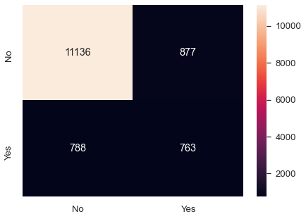

```python
# Confusion Matrix

y_predict = Level1.predict(X_test)
print("Decision Tree score ",Level1.score(X_test , y_test).round(4))
cm=metrics.confusion_matrix(y_test, y_predict,labels=[0, 1])
df_cm = pd.DataFrame(cm, index = [i for i in ["No","Yes"]],columns = [i for i in ["No","Yes"]])
plt.figure(figsize = (7,5))
sns.heatmap(df_cm, annot=True ,fmt='g')
```

```python
# Model performance
from sklearn import metrics
Y_predicts = np.around(Level1.predict(X_test))
print("Precision Score: ",metrics.precision_score(y_test,Y_predicts).round(2),'\n')
print(metrics.classification_report(y_test,Y_predicts))
```

```
Precision Score:  0.47

              precision    recall  f1-score   support

           0       0.93      0.93      0.93     12013
           1       0.47      0.49      0.48      1551

    accuracy                           0.88     13564
   macro avg       0.70      0.71      0.70     13564
weighted avg       0.88      0.88      0.88     13564
```

# Feature Engineering with - Grid Search

**Huge difference between Train and Test scores, clearly shows the Train data over fitted.**

**Need to work on Feature Engineering**</font>

**Note: -** Decision Tree is a non-parametric algorithm and hence prone to overfitting easily. This is evident from the difference in scores in training and testing. In ensemble techniques, we want multiple instances (each different from the other) and each instance to be overfit. Hopefully, the different instances will do different mistakes in classification and when we club them, their# errors will get cancelled out giving us the benefit of lower bias and lower overall variance errors.

```python
#Feature Engineering with - Grid Search
Parameter = {
     "criterion": ['gini', 'entropy'],
     "max_depth": [2,3,4],
     "splitter": ["best","random"],
     "min_samples_leaf": [2,3,4,5]}
tree = GridSearchCV(DecisionTreeClassifier(), param_grid=Parameter)
tree.fit(X_train, y_train)

tree.best_params_

#
# GRID SEARCH WOULD TAKE LONGER TIME - SO COPIED THE RESULT FROM THE EARLIER RUN
#
#{'criterion': 'gini',
# 'max_depth': 4,
# 'min_samples_leaf': 4,
# 'splitter': 'random'}
```

```
{'criterion': 'gini',
 'max_depth': 4,
 'min_samples_leaf': 3,
 'splitter': 'random'}
```

```python
# Decision Tree with best feature
DT = DecisionTreeClassifier(criterion = "gini", max_depth=4, min_samples_leaf = 1, min_samples_split = 2, splitter = "best")
DT.fit(X_train, y_train)
print("Train: %.4f" % DT.score(X_train, y_train))  # performance on train data
print("Test: %.4f" % DT.score(X_test, y_test))  # performance on test data
```

```
Train: 0.8921
Test: 0.8893
```

```python
# Predictions for Confusion matrix
Predicts_Train = DT.predict(X_train)
Predicts_Test = DT.predict(X_test)

score_DT = accuracy_score(y_test, Predicts_Test)

# Confusion matrix
pd.crosstab(y_test, Predicts_Test, rownames=['Actual'], colnames=['Predicted'])
```

| Predicted Actual | 0 | 1 |
| --- | --- | --- |
| 0 | 11379 | 634 |
| 1 | 868 | 683 |

```
Decision Tree score  0.8893
```

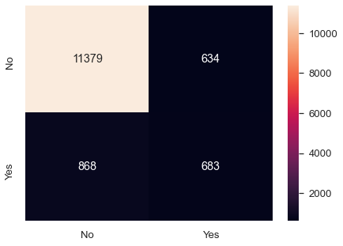

```python
# Confusion Matrix

y_predict = DT.predict(X_test)
print("Decision Tree score ",DT.score(X_test , y_test).round(4))
cm=metrics.confusion_matrix(y_test, y_predict,labels=[0, 1])
df_cm = pd.DataFrame(cm, index = [i for i in ["No","Yes"]],columns = [i for i in ["No","Yes"]])
plt.figure(figsize = (7,5))
sns.heatmap(df_cm, annot=True ,fmt='g')
```

```python
# Model performance
from sklearn import metrics
Y_predicts = np.around(DT.predict(X_test))
print("Precision Score: ",metrics.precision_score(y_test,Y_predicts).round(2),'\n')
print(metrics.classification_report(y_test,Y_predicts))
```

```
Precision Score:  0.52

              precision    recall  f1-score   support

           0       0.93      0.95      0.94     12013
           1       0.52      0.44      0.48      1551

    accuracy                           0.89     13564
   macro avg       0.72      0.69      0.71     13564
weighted avg       0.88      0.89      0.89     13564
```

```
ROCAUC(ax=<AxesSubplot:>, binary=None, model=None)
```

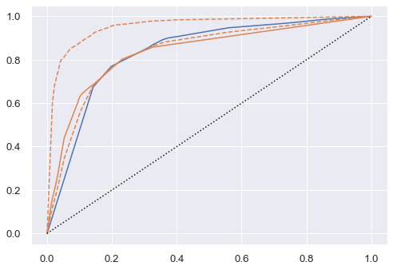

```python
# ROC - Visualize model performance with yellowbrick library
from yellowbrick.classifier import  ROCAUC

roc = ROCAUC(DecisionTreeClassifier(criterion = "gini", max_depth=4))
roc.fit(X_train, y_train)
roc.score(X_test, y_test)
roc
```

```python
#Feature Engineering - Predictive power of each coloumn
features = [col for col in pdata.columns if col != 'Target' and col !='default']
feat_importance = DT.tree_.compute_feature_importances(normalize=False)


feat_imp_dict = dict(zip(features, DT.feature_importances_))
feat_imp = pd.DataFrame.from_dict(feat_imp_dict, orient='index')
feat_imp.sort_values(by=0, ascending=False)
```

|  | 0 |
| --- | --- |
| duration | 0.657874 |
| pdays | 0.111861 |
| housing | 0.107525 |
| age | 0.048708 |
| contact_unknown | 0.027526 |
| month | 0.024367 |
| poutcome | 0.012817 |
| contact_cellular | 0.005902 |
| day | 0.003420 |
| loan | 0.000000 |
| balance | 0.000000 |
| job | 0.000000 |
| education | 0.000000 |
| previous | 0.000000 |
| marital_divorced | 0.000000 |
| marital_married | 0.000000 |
| marital_single | 0.000000 |
| contact_telephone | 0.000000 |
| campaign | 0.000000 |

```python
#Store the score of each model for final comparison
Result = pd.DataFrame({'Method':['Logistic Regression'], 'Accuracy': score_LR})
Final = Result[['Method', 'Accuracy']]
Final
```

|  | Method | Accuracy |
| --- | --- | --- |
| 0 | Logistic Regression | 0.890224 |

```python
#Store the score of each model for final comparison
temp = pd.DataFrame({'Method':['Decision Tree'], 'Accuracy': score_DT})
Final = pd.concat([Final, temp])
Final = Final[['Method', 'Accuracy']]
Final
```

|  | Method | Accuracy |
| --- | --- | --- |
| 0 | Logistic Regression | 0.890224 |
| 0 | Decision Tree | 0.889266 |

# Random Forest Classifier Algorithm

```python
#Feature Engineering with - Grid Search
#Parameter = {
#     "criterion": ['gini', 'entropy'],
#     "max_depth": [2,3,4],
#     "max_features": ["auto","sqrtm","log2"],
#     "class_weight": ["balanced", "balanced_subsample"],
#     "min_samples_split": [2,3,4,5]}

#tree = GridSearchCV(RandomForestClassifier(), param_grid=Parameter)
#tree.fit(X_train, y_train)

#tree.best_params_
# GRID SEARCH WOULD TAKE LONGER TIME - SO COPIED THE RESULT FROM THE EARLIER RUN

#{'class_weight': 'balanced',
# 'criterion': 'entropy',
# 'max_depth': 4,
# 'max_features': 'auto',
# 'min_samples_split': 3}
```

```python
# Random Forest Classifier
from sklearn.ensemble import RandomForestClassifier
RF = RandomForestClassifier(criterion = 'entropy',  n_estimators = 100, max_depth=4)
RF = RF.fit(X_train, y_train)

# Precit for Test
Predict_RF = RF.predict(X_test)
score_RF = accuracy_score(y_test, Predict_RF)

# Random Forest score
print("Train: %.4f" % RF.score(X_train, y_train))  # performance on train data
print("Test: %.4f" % RF.score(X_test, y_test))  # performance on test data
```

```
Train: 0.8837
Test: 0.8869
```

```python
# Predictions for Confusion matrix
Predicts_Train = RF.predict(X_train)
Predicts_Test = RF.predict(X_test)

score_RF = accuracy_score(y_test, Predicts_Test)

# Confusion matrix
pd.crosstab(y_test, Predicts_Test, rownames=['Actual'], colnames=['Predicted'])
```

| Predicted Actual | 0 | 1 |
| --- | --- | --- |
| 0 | 12008 | 5 |
| 1 | 1529 | 22 |

```
Random Forest score  0.8869
```

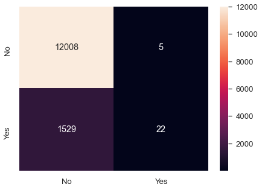

```python
# Confusion Matrix

y_predict = RF.predict(X_test)
print("Random Forest score ",RF.score(X_test , y_test).round(4))
cm=metrics.confusion_matrix(y_test, y_predict,labels=[0, 1])
df_cm = pd.DataFrame(cm, index = [i for i in ["No","Yes"]], columns = [i for i in ["No","Yes"]])
plt.figure(figsize = (7,5))
sns.heatmap(df_cm, annot=True ,fmt='g')
```

```python
#Performance Indicators
print("Recall:",recall_score(y_test,y_predict).round(4))
print("Precision:",precision_score(y_test,y_predict).round(4))
print("F1 Score:",f1_score(y_test,y_predict).round(4))
print("Roc Auc Score:",roc_auc_score(y_test,y_predict).round(4))
```

```
Recall: 0.0142
Precision: 0.8148
F1 Score: 0.0279
Roc Auc Score: 0.5069
```

```python
# Model performance
from sklearn import metrics
Y_predicts = np.around(RF.predict(X_test))
print("Precision Score: ",metrics.precision_score(y_test,Y_predicts).round(2),'\n')
print(metrics.classification_report(y_test,Y_predicts))
```

```
Precision Score:  0.81

              precision    recall  f1-score   support

           0       0.89      1.00      0.94     12013
           1       0.81      0.01      0.03      1551

    accuracy                           0.89     13564
   macro avg       0.85      0.51      0.48     13564
weighted avg       0.88      0.89      0.84     13564
```

```
ROCAUC(ax=<AxesSubplot:>, binary=None, model=None)
```

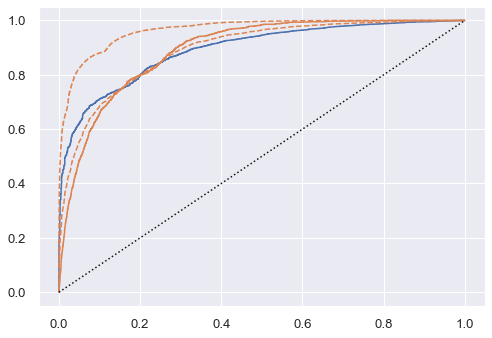

```python
# ROC - Visualize model performance with yellowbrick library
from yellowbrick.classifier import  ROCAUC
roc = ROCAUC(RandomForestClassifier(criterion = 'entropy',  n_estimators = 50, max_depth=4, max_features = 'auto', min_samples_split = 3))
roc.fit(X_train, y_train)
roc.score(X_test, y_test)
roc
```

```python
#Store the score of each model for final comparison
temp = pd.DataFrame({'Method':['Random Forest'], 'Accuracy': score_RF})
Final = pd.concat([Final, temp])
Final = Final[['Method', 'Accuracy']]
Final
```

|  | Method | Accuracy |
| --- | --- | --- |
| 0 | Logistic Regression | 0.890224 |
| 0 | Decision Tree | 0.889266 |
| 0 | Random Forest | 0.886907 |

```python
# Random Forest Feature Influencers
RF.feature_importances_
```

```
array([4.27118388e-02, 6.19683853e-03, 1.67696081e-03, 1.59721331e-02,
       5.15073759e-02, 5.65716964e-03, 8.22198841e-03, 4.36345131e-02,
       4.69252154e-01, 8.29165873e-03, 8.10236253e-02, 5.15523490e-02,
       8.14679829e-02, 1.77228529e-04, 3.15417578e-03, 2.61106941e-03,
       4.84598318e-02, 1.85295394e-03, 7.65781524e-02])
```

```
<BarContainer object of 19 artists>
```

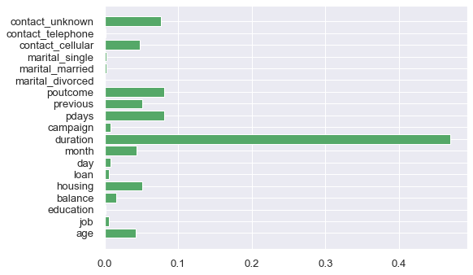

```python
# Random Forest Feature Influencers
plt.barh(features, RF.feature_importances_, color='g')
```

**Observation**

**Random Forest** </font>

# Bagging Classifier Algorithm

```python
#Feature Engineering with - Grid Search
#Parameter = {
#     "max_samples": [.7,.5,.1],
#     "max_features": [1,2]}

#tree = GridSearchCV(BaggingClassifier(), param_grid=Parameter)
#tree.fit(X_train, y_train)

#tree.best_params_

# GRID SEARCH WOULD TAKE LONGER TIME - SO COPIED THE RESULT FROM THE EARLIER RUN
#{'max_features': 2, 'max_samples': 0.1}
```

```python
from sklearn.ensemble import BaggingClassifier
BG = BaggingClassifier(n_estimators=50, max_samples= .1, max_features = 2, bootstrap=True, oob_score=True, random_state=22)
BG = BG.fit(X_train, y_train)

Predicted_BG = BG.predict(X_test)
score_BG = accuracy_score(y_test, Predicted_BG)


print("Train: %.4f" % BG.score(X_train, y_train))  # performance on train data
print("Test: %.4f" % BG.score(X_test, y_test))  # performance on test data
```

```
Train: 0.8819
Test: 0.8857
```

```python
#Store the score of each model for final comparison
Result = pd.DataFrame({'Method':['Bagging'], 'Accuracy': [score_BG]})
Final = pd.concat([Final, Result])
Final = Final[['Method', 'Accuracy']]
Final
```

|  | Method | Accuracy |
| --- | --- | --- |
| 0 | Logistic Regression | 0.890224 |
| 0 | Decision Tree | 0.889266 |
| 0 | Random Forest | 0.886907 |
| 0 | Bagging | 0.885653 |

```python
# Model performance
from sklearn import metrics
Y_predicts = np.around(BG.predict(X_test))
print("Precision Score: ",metrics.precision_score(y_test,Y_predicts).round(2),'\n')
print(metrics.classification_report(y_test,Y_predicts))
```

```
Precision Score:  0.0

              precision    recall  f1-score   support

           0       0.89      1.00      0.94     12013
           1       0.00      0.00      0.00      1551

    accuracy                           0.89     13564
   macro avg       0.44      0.50      0.47     13564
weighted avg       0.78      0.89      0.83     13564
```

```
ROCAUC(ax=<AxesSubplot:>, binary=None, model=None)
```

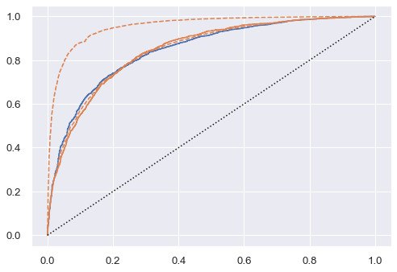

```python
# ROC - Visualize model performance with yellowbrick library
from yellowbrick.classifier import  ROCAUC

roc = ROCAUC(BaggingClassifier(n_estimators=50, max_samples= .1, max_features = 2, bootstrap=True, oob_score=True, random_state=22))
roc.fit(X_train, y_train)
roc.score(X_test, y_test)
roc
```

**Observation**

**Bagging** </font>

**Insights from the Bagging Technique**

- As per the objective we are going to consider Accuracy score, True Posive and Precision_1.
- For Bagging Technique accuracy 88.56% however the True Positive (0) and precision_1 (0) not enough for decision
- Decided to try for Ensamble Technique and Random Forest for better technique

# Adaboost Ensemble Algorithm

```python
#Feature Engineering with - Grid Search
#Parameter = {
#     "algorithm": ['SAMME', 'SAMME.R'],
#     "n_estimators": [50,100],
#     "learning_rate": [0.1,0.2]}

#tree = GridSearchCV(AdaBoostClassifier(), param_grid=Parameter)
#tree.fit(X_train, y_train)

#tree.best_params_

# GRID SEARCH WOULD TAKE LONGER TIME - SO COPIED THE RESULT FROM THE EARLIER RUN

#{'algorithm': 'SAMME.R', 'learning_rate': 0.2, 'n_estimators': 100}
```

```python
from sklearn.ensemble import AdaBoostClassifier
AB = AdaBoostClassifier(algorithm = 'SAMME.R', n_estimators = 100, learning_rate=0.2, random_state=22)
AB = AB.fit(X_train, y_train)

Predicted_AB =AB.predict(X_test)
score_AB = accuracy_score(y_test, Predicted_AB)

print("Train: %.4f" % AB.score(X_train, y_train))  # performance on train data
print("Test: %.4f" % AB.score(X_test, y_test))  # performance on test data
```

```
Train: 0.8942
Test: 0.8935
```

```
Ada Booster score  0.8935
```

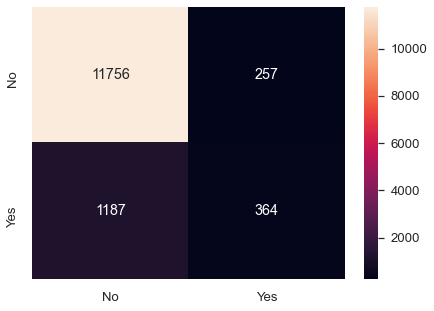

```python
# Confusion Matrix

y_predict = AB.predict(X_test)
print("Ada Booster score ",AB.score(X_test , y_test).round(4))
cm=metrics.confusion_matrix(y_test, y_predict,labels=[0, 1])
df_cm = pd.DataFrame(cm, index = [i for i in ["No","Yes"]], columns = [i for i in ["No","Yes"]])
plt.figure(figsize = (7,5))
sns.heatmap(df_cm, annot=True ,fmt='g')
```

```python
#Store the score of each model for final comparison
Result = pd.DataFrame({'Method':['Adaboost'], 'Accuracy': [score_AB]})
Final = pd.concat([Final, Result])
Final = Final[['Method', 'Accuracy']]
Final
```

|  | Method | Accuracy |
| --- | --- | --- |
| 0 | Logistic Regression | 0.890224 |
| 0 | Decision Tree | 0.889266 |
| 0 | Random Forest | 0.886907 |
| 0 | Bagging | 0.885653 |
| 0 | Adaboost | 0.893542 |

```python
# Model performance
from sklearn import metrics
Y_predicts = np.around(AB.predict(X_test))
print("Precision Score: ",metrics.precision_score(y_test,Y_predicts).round(2),'\n')
print(metrics.classification_report(y_test,Y_predicts))
```

```
Precision Score:  0.59

              precision    recall  f1-score   support

           0       0.91      0.98      0.94     12013
           1       0.59      0.23      0.34      1551

    accuracy                           0.89     13564
   macro avg       0.75      0.61      0.64     13564
weighted avg       0.87      0.89      0.87     13564
```

```
ROCAUC(ax=<AxesSubplot:>, binary=None, model=None)
```

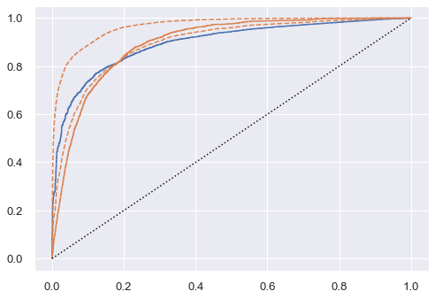

```python
# ROC - Visualize model performance with yellowbrick library
from yellowbrick.classifier import  ROCAUC

roc = ROCAUC(AdaBoostClassifier(algorithm = 'SAMME.R', n_estimators = 100, learning_rate=0.2, random_state=22))
roc.fit(X_train, y_train)
roc.score(X_test, y_test)
roc
```

```python
#AdaBoost Feature Influencers
AB.feature_importances_
```

```
array([0.09, 0.02, 0.02, 0.04, 0.05, 0.02, 0.01, 0.12, 0.27, 0.04, 0.06,
       0.  , 0.19, 0.  , 0.01, 0.01, 0.  , 0.  , 0.05])
```

```
<BarContainer object of 19 artists>
```

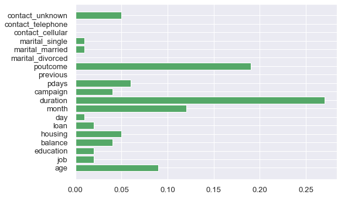

```python
#AdaBoost Feature Influencers
plt.barh(features, AB.feature_importances_, color='g')
```

**Observation**

**AdaBoost** </font >

- Accuracy_score 0.8935
- precision_0 0.91
- precision_1 0.59
- True Positive 364
- True Nagive 11756

**Insights from the AdaBoost Technique**</font >

- As per the objective we are going to consider Accuracy score, True Posive and Precision_1.
- For AdaBoost Technique accuracy 89.35% however the True Positive (364) and precision_1 (0.59) not enough for decision
- Decided to try for Ensamble Technique and Gradiant Technique for better results
- Duration, poutcome, month, age are the top contributor according to AdaBoost Ensamble Technique

# GradientBoost Ensemble Algorithm</font >

```python
#Feature Engineering with - Grid Search
from sklearn.ensemble import GradientBoostingClassifier
#Parameter = {
#     "loss": ['deviance', 'exponential'],
#     "criterion": ['friedman_mse', 'mse', 'mae'],
#     "max_depth": [3,4,5]}

#tree = GridSearchCV(GradientBoostingClassifier(), param_grid=Parameter)
#tree.fit(X_train, y_train)

#tree.best_params_
```

```python
# Gradient Booster Algorithm

from sklearn.ensemble import GradientBoostingClassifier
GB = GradientBoostingClassifier(n_estimators = 50, learning_rate = 0.1, random_state=22)
GB = GB.fit(X_train, y_train)

Predicted_GB = GB.predict(X_test)
score_GB = accuracy_score(y_test, Predicted_GB)

print("Train: %.4f" % GB.score(X_train, y_train))  # performance on train data
print("Test: %.4f" % GB.score(X_test, y_test))  # performance on test data
```

```
Train: 0.9048
Test: 0.9017
```

```
Gradiant Booster score  0.9017
```

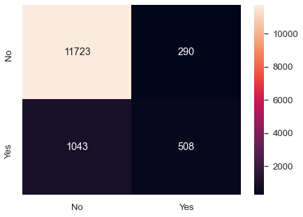

```python
# Confusion Matrix

y_predict = GB.predict(X_test)
print("Gradiant Booster score ",GB.score(X_test , y_test).round(4))
cm=metrics.confusion_matrix(y_test, y_predict,labels=[0, 1])
df_cm = pd.DataFrame(cm, index = [i for i in ["No","Yes"]],columns = [i for i in ["No","Yes"]])
plt.figure(figsize = (7,5))
sns.heatmap(df_cm, annot=True ,fmt='g')
```

```python
# Model performance
from sklearn import metrics
Y_predicts = np.around(GB.predict(X_test))
print("Precision Score: ",metrics.precision_score(y_test,Y_predicts).round(2),'\n')
print(metrics.classification_report(y_test,Y_predicts))
```

```
Precision Score:  0.64

              precision    recall  f1-score   support

           0       0.92      0.98      0.95     12013
           1       0.64      0.33      0.43      1551

    accuracy                           0.90     13564
   macro avg       0.78      0.65      0.69     13564
weighted avg       0.89      0.90      0.89     13564
```

```
ROCAUC(ax=<AxesSubplot:>, binary=None, model=None)
```

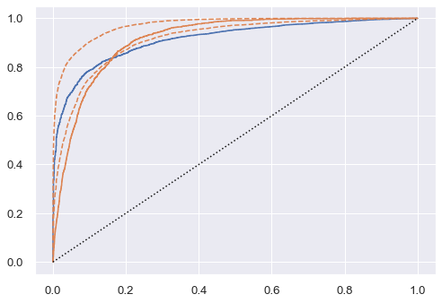

```python
# ROC - Visualize model performance with yellowbrick library
from yellowbrick.classifier import  ROCAUC

roc = ROCAUC(GradientBoostingClassifier(n_estimators = 50, learning_rate = 0.1, random_state=22))
roc.fit(X_train, y_train)
roc.score(X_test, y_test)
roc
```

```python
# Gradient Booster - Feature Influencers
GB.feature_importances_
```

```
array([5.02679789e-02, 1.32721726e-03, 3.74345080e-03, 7.58446313e-03,
       6.98047500e-02, 4.31093098e-03, 1.96170027e-02, 5.41880583e-02,
       5.27724629e-01, 5.63154355e-03, 7.72492424e-02, 1.95331170e-03,
       1.23736972e-01, 2.54122015e-04, 4.00968728e-03, 5.43464410e-04,
       4.26222000e-03, 0.00000000e+00, 4.37909554e-02])
```

```
<BarContainer object of 19 artists>
```

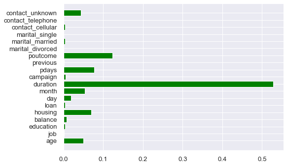

```python
# Gradient Booster - Feature Influencers
plt.barh(features, GB.feature_importances_, color='Green')
```

```python
#Store the score of each model for final comparison

print('\033[1m' + '\033[95m' + 'HERE ARE THE FINAL ACCURACY LIST:' + '\033[0m')

Result = pd.DataFrame({'Method':['Gradient Boost'], 'Accuracy': [score_GB]})
Final = pd.concat([Final, Result])
Final = Final[['Method', 'Accuracy']]
Final
```

```
HERE ARE THE FINAL ACCURACY LIST:
```

|  | Method | Accuracy |
| --- | --- | --- |
| 0 | Logistic Regression | 0.890224 |
| 0 | Decision Tree | 0.889266 |
| 0 | Random Forest | 0.886907 |
| 0 | Bagging | 0.885653 |
| 0 | Adaboost | 0.893542 |
| 0 | Gradient Boost | 0.901725 |

**Observation**

**Gradiant Boost**

- Accuracy_score 0.90.17
- precision_0 0.92
- precision_1 0.64
- True Positive 508
- True Nagive 11723

**Insights from the Gradiant Boost Technique**

### Precision and Recall:

- Recall: It is the ratio of total number of "Yes" in the label column of the dataset to the number of "Yes" labels does our model detect.
- Precision: Means how sure is the prediction of our model that the actual label is a "Yes".
- Here the company wants more people to subscribe to term deposits. So if we have a customer who is willing to subscribe then we shouldn't loose that customer. Therefore focus shpould be on False negative. Decreasing FN and increasing recall.

**This Gradiant Booster**

**Duration, poutcome, contact_unknown, pdays, housing, month, age are important features according to Ensamble Technique derived above**

# Business Recommendation

- When implementing a marketing strategy, external factors, such as the time of calling, should also be carefully considered. The previous analysis points out that March, September, October and December had the highest success rates. So, these months should be targeted by the bank to approach customers.
- We saw that students and retired people are more likely to subcribe for the term deposit. Bank can identify this and can prioritize their strategy for these people to be better.
- Marital status, occupation or whether they have previous loan or not reveal a customer's life stage and indicates his/her overall risk profile. With this information, the bank can estimate when a customer can/will make an investment.
- Bank can target individuals with higher call duration as we saw they are more likely to go for the term deposit.
- We can focus on the features which the model has given top preference while calculating the result.
- As data scientists, we can further increase the recall rate for 'yes' class or get more data to make the model better. Then, we can deploy that model in production and can identify the whether that customer would opt for the term depost or not based on the feature imformation we have.